# Species Distribution Modelling with MaxEnt in R

Dony Indiarto

## Chapter 1 Introduction

Synonyms: Climate modelling envelope, habitat modelling, and niche-modeling.

Main Aim: to estimate the similarity of the condition at any site to the conditions at any sites to the conditions at the locations of known occurence of a phenomenon.

##### Major steps in SDMs:

1. a compilation of species occurence locations
2. values of environmental predictor variables (such as climate), extracted from climate databases
3. model fitting
4. prediction of variable of interest across an the region of interest

Required packages: **install.packages(c(’raster’, ’rgdal’, ’dismo’, ’rJava’))**

## Chapter 2 Species occurence data

All model perform better with unbiased and error-free data. Garbage in garbage out applies.

> Improving the quality of occurrence data first, model comparison second.

```r
#load libraries
library(raster)
library(rgdal)
library(dismo)
library(rJava)
library(readr)
```

### 2.1 Presence data input arrangements

```r
#load occurence dataset: Bradypus data example
 bradypus <- read_csv(paste(system.file(package="dismo"), "/ex/bradypus.csv", sep=""))
head(bradypus)
```

| species | lon | lat |
| --- | --- | --- |
| Bradypus variegatus | -65.4000 | -10.3833 |
| Bradypus variegatus | -65.3833 | -10.3833 |
| Bradypus variegatus | -65.1333 | -16.8000 |
| Bradypus variegatus | -63.6667 | -17.4500 |
| Bradypus variegatus | -63.8500 | -17.4000 |
| Bradypus variegatus | -64.4167 | -16.0000 |

Species occurence dataframe consists of:

1. species name
2. x or longitude
3. y or latitude

Dismo uses the old GBIF API therefore use occ function from spocc package (Interface to many species occurrence data sources):

### 2.2 Load data from GBIF

```r
library(spocc)
acaule<- occ(query="Solanum acaule", from='gbif', limit=10000)
acaule<-acaule$gbif$data$Solanum_acaule
#data dimension
dim(acaule)
```

```
[1] 6408  116
```

```r
#data column names
colnames(acaule)
```

```
  [1] "name"                     "longitude"
  [3] "latitude"                 "issues"
  [5] "prov"                     "key"
  [7] "datasetKey"               "publishingOrgKey"
  [9] "publishingCountry"        "protocol"
 [11] "lastCrawled"              "lastParsed"
 [13] "crawlId"                  "basisOfRecord"
 [15] "taxonKey"                 "kingdomKey"
 [17] "phylumKey"                "classKey"
 [19] "orderKey"                 "familyKey"
 [21] "genusKey"                 "scientificName"
 [23] "kingdom"                  "phylum"
 [25] "order"                    "family"
 [27] "genus"                    "genericName"
 [29] "specificEpithet"          "taxonRank"
```

[output cut: 43 more lines]

```r
library(plyr)
acaule$country<-revalue(acaule$country, c("Bolivia, Plurinational State of"="Bolivia"))
```

### 2.3 Data cleaning

#### 2.3.1 Unfiltered data visualisation

Create a map of species occurence

```r
#data filtering, select the records that have longitude and latitude data
acgeo <- (subset(acaule, !is.na(longitude) & !is.na(latitude)))
dim(acgeo)
```

```
[1] 4186  116
```

```r
library(maptools)
data("wrld_simpl") # lightweight global map, not reccomended for
plot(wrld_simpl, xlim=c(-40,20), ylim=c(-70,70), axes=T, col='light yellow')
box()
```

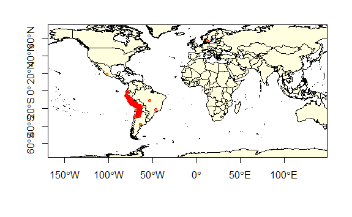

```r
points(acgeo$longitude, acgeo$latitude, col='orange', pch=20, cex=0.75)
 points(acgeo$longitude, acgeo$latitude, col='red', cex=0.75)
```

```r
NA
```

*Solanum acaule* presents in the higher parts of the Andes mountains of southern Peru, Bolivia, and Northern Argentina.

As we see from the map, there are some errors occured. Points in Sweden, Mexico, Southern argentina, and Brazil might not be true. Background knowledge on species distribution is required.

Common mistakes:

1. missing minus signs
2. duplicates (identical data points that were submitted twice or more)
3. latitude/longitude typo
4. 0 coordinates where ‘NAs’ were intended (not georeferenced yet, we can apply “geo=FALSE option to get non-georeferenced recodrs, some of it may have a textual georeference or locality description”)
5. Some data records in GBIF coes with uncertaint asscociated with the georeferences.